# 弾性力学および熱弾性力学入門

著：R. J. BOLLARD, Ph.D.

# 章 A24

## 熱弾性力学の3次元方程式

**A24.1 仮定**: 古典的な弾性力学理論において、その全領域にわたる弾性体の状態に関して、最も重要な2つの仮定が存在する。

1. 材料は均質（homogeneous）である。
2. 材料は等方性（isotropic）である。

第1の仮定は、弾性体がその体積全体および表面上のすべての点において、同一の材料特性を持つことを要求する。均質性が存在しない場合、例えば異物の混入がある場合や、積層構造の各層で異なる材料が用いられている場合、機械的定数および弾性定数は物体内の位置の関数となる。また、不均一に加熱された物体において材料特性が温度の関数となる場合もこれに該当する。

第2の仮定は、弾性体内の任意の点において、弾性特性がすべての方向で同一であることを要求する。押出成形された黒鉛や積層プラスチックのように材料が非等方性である場合、応力とひずみの関係は、2つの独立した弾性定数を含む単純な方程式ではなくなる。最も一般的な非等方性材料では、応力ひずみ関係を定義するために21個の弾性定数を必要とする。弾性対称面の存在により、この数は減少する[^1]。

第3の重要な仮定は、変位が十分に小さいため、変形後に物体内の点の位置を再定義する必要がなく、変位の微分の高次項が無視できることである。これらの仮定が成り立たない場合、ひずみと変位の関係は非線形となり、はるかに困難な大変形理論を用いなければならなくなる。

最後の仮定は、材料が弾性的に振る舞うことである。この仮定は、外力による荷重であれ温度であれ、変形原因を取り除いたとき、変形した物体が元の形状に戻ることを要求する。単純な引張応力-ひずみ曲線を考えると、この仮定は、物体内のどの点においても応力レベルが降伏点を超えてはならないことを要求する。この応力レベルを超えると、応力ひずみ関係はもはやフックの法則に従わなくなるため、問題は再び非線形となる。この非線形応答は、塑性力学理論においてモデル化されている。また、古典的な弾性力学理論の適用において、材料の粘弾性挙動を無視することが一般的であるが、応力とひずみの線形時間微分のみを含む応力ひずみ関係へのこのケースの拡張は非常に単純である。このような挙動（最もよく知られているのはクリープ）は温度が上昇するにつれて顕著になるため、線形ケースにおけるこの可能な拡張については章 A27で説明する。

これら最後の2つの仮定（微小変形および線形応力ひずみ関係）に反し、当然ながら重ね合わせの理が適用できなくなる非線形問題へ至ることについては、混乱を招くためではなく、本書で提示する理論の限界に対する警告として言及している。

**A24.2 熱弾性力学の3次元方程式の定式化**

熱弾性力学の問題は、外力および拘束を受ける加熱された弾性体の内部および境界上の任意の点において、応力、ひずみ、および変位を決定することである。物体の内部または境界上の任意の選択された点における応力状態は、その点において力とモーメントの釣り合いが存在するようなものでなければならない。したがって、応力成分の釣り合い状態の表現は、材料特性、変形、温度および温度分布、応力ひずみ法則などには依存しない。応力成分間の関係は、単に釣り合い方程式を満足するものでなければならない。よく知られているように、ある点における応力は、選択された方向の力強度であり、選択された仮想的な切断面に関連する大きさと方向を持つ、単一のベクトルで表すことができる。

この応力フィールドの影響下で、弾性体は応力ひずみ関係に依存する方法で変形する。等温問題（全体が同じ温度）に対する応力ひずみ関係は、線形フックの法則からよく知られている[^2][^3][^3]。温度の導入は、研究対象の材料の熱膨張特性による別のひずみ成分を追加することによって、これらの関係を修正する。これらの応力ひずみ関係はさらに6つの方程式を提供するが、同時に6つの新たな未知のひずみ成分が導入される。方程式系はまだ不完全である。

ひずみは変位を生じさせる。温度および温度分布に依存しないひずみと変位の関係は、定義のために6つの方程式を必要とし、同時に変位成分である3つの未知数のみを導入する。

未知数の数は現在18であり、18の方程式が存在するため、方程式系は完全であり、一般解が可能である。この一般解は、18すべての方程式が同時に満たされる場合の唯一の解となる。特定の問題に対する解の開発には、一般解に存在する未知の係数を評価するための境界条件方程式のセットが必要である。

弾性力学理論と同様に、熱弾性力学における選択された物理的問題への解は、定義された18の方程式セットを満たし、さらに境界条件を満たさなければならない。熱弾性力学の方程式は、以下のセクションにおいて以下の順序で導出される。

1. 釣り合い方程式
2. ひずみ - 変位関係
3. 応力 - ひずみ関係
4. 境界条件

現時点で、線形弾性力学理論の熱弾性力学理論への変更に必要なのは、応力ひずみ関係のみであることに注意すべきである。

### A24.3 釣り合い方程式

外力および内部力（体積力）を受ける弾性体内の点 $O$ を考える。点 $O$ における応力状態を決定することが望まれる。これは、何らかの空間的参照に対する合成応力テンソルを定義することによって完全に実行できるが、最も一般的には次のように行われる。関心のある点 $O$ を、選択された空間直交座標系に平行に配向された3つの互いに垂直な軸の原点とする。この参照軸系の選択は、通常、研究対象のシステムの幾何学的形状によって明確に示される。

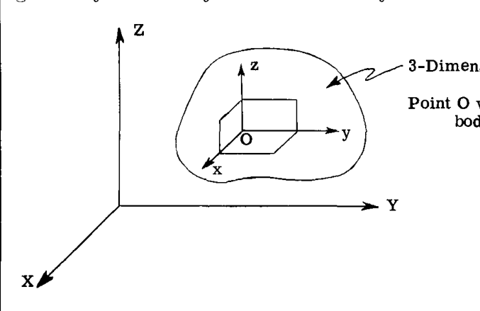

3次元物体と点O

平面 $xy$ , $xz$ , $yz$ が共通の交点 $O$ を持つように物体が切断されていると仮定する。これらの切断面のそれぞれに関連して、定義のために3つの成分を必要とする、点 $O$ における合成応力ベクトルが存在する。これらの成分の方向を座標軸の方向として選択することが論理的である。

例えば、切断面 $yz$ を考える。この切断面に関連する $O$ での合成応力ベクトルは、3つの成分 $\sigma_x, \tau_{xy}, \tau_{xz}$ によって定義できる。ここで：

- $\sigma_x$ = $zy$ 平面に垂直で、したがって $x$ 軸に平行な成分（それゆえ下付き文字 $x$ ）。
- $\tau_{xy}$ = $yz$ 平面内の応力成分の1つで、法線方向 $x$ （最初の部分付き文字）によって識別され、2番目の下付き文字で示される $y$ 方向の成分。この成分は $\tau_{(yz)y}$ と書くこともできるが、軸が互いに垂直であるため、示されているように下付き文字 $x$ で識別する方が簡潔である。
- $\tau_{xz}$ = $\tau_{xy}$ と直角をなす、平面内のもう1つの成分。ここでも、最初の部分付き文字が切断面 $yz$ を識別し、2番目が方向を示す。

符号規則を採用することにより、これらのベクトル成分はスカラー量とみなすことができる。切断面 $xz$ には成分 $\sigma_y, \tau_{yx}, \tau_{yz}$ が関連付けられ、切断面 $xy$ には成分 $\sigma_z, \tau_{zx}, \tau_{zy}$ が関連付けられる。 $O$ を通る他の無数に存在する可能性のある切断面は、3つの互いに垂直な平面 $xy, xz, yz$ に関連付けられた座標に関して定義できる。したがって、9つの応力成分 $\sigma_x, \sigma_y, \sigma_z, \tau_{xy}, \tau_{xz}, \tau_{yx}, \tau_{yz}, \tau_{zx}, \tau_{zy}$ の定義は、物体内の点 $O$ における応力状態を完全に定義する。これらのベクトル成分の大きさは、釣り合いの微分方程式、応力ひずみ、およびひずみ変位関係、ならびに境界条件の解から得られる。ここで、図示された符号規則が常に暗示され、方向が選択された直交座標系の方向であるため、成分はスカラー量として扱われる。

釣り合い方程式を確立するために、静力学の基本法則が採用される：

$$\Sigma F_x = \Sigma F_y = \Sigma F_z = \Sigma M_o = 0$$

ここで、 $F_x$ は $x$ 方向の力を示し、 $M_o$ は $O$ まわりのモーメントを示す。

これらの方程式を満たすのは力であるため、応力（力強度である）が作用している表面積を提供しなければならない。これは、直交座標系に含まれる切断面内またはそれに平行な面を持つ、原点として関心のある点 $O$ を持つ小さな平行六面体の面の上に作用する応力成分を考慮することによって最も便利に行われる。この平行六面体は任意に小さいと考えられ、極限においてエッジ寸法がゼロに近づくとき、要素の釣り合いから生じる方程式は、点 $O$ における応力状態を記述する。そこで、エッジ寸法が $dx, dy, dz$ と正しく指定された、すでに無限小と考えられているそのような平行六面体を考える。切断面 $xz, xy, yz$ に含まれる面上の応力成分が、正の符号規則に従って示されている。

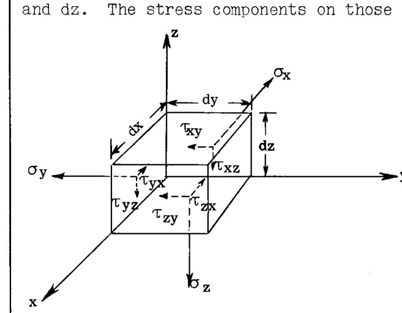

微小要素における応力成分

この同じ符号規則に従って、切断面に平行な面上の応力成分が次の図に示されている。限界プロセスにより、これらは $O$ における応力状態の物理的解釈から関心のある成分であり、釣り合いの微分方程式の解における正の値によって示されるのはこれらの方向である。 $\sigma_x, \sigma_y, \sigma_z$ の正の値は、点 $O$ における弾性材料の引張を示すことが観察される。

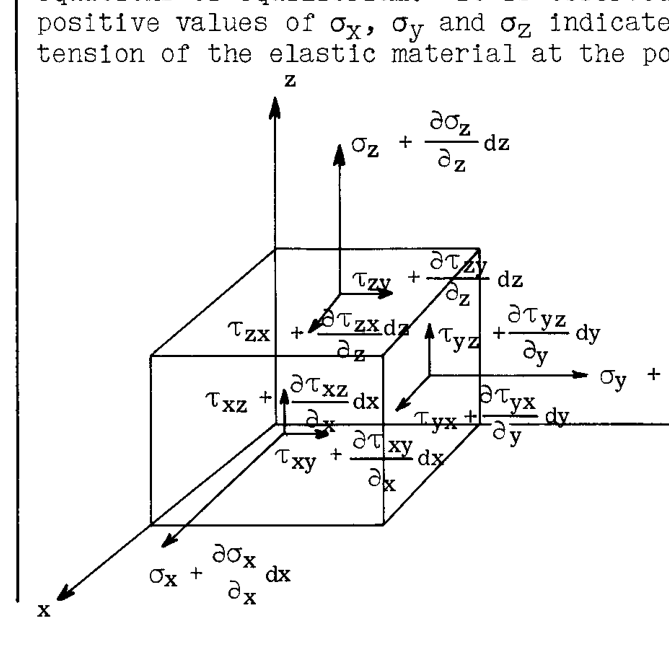

微小要素の平行な面における応力成分と増分

弾性方程式の解の物理的解釈中に疑問が生じた場合は、応力成分の正の方向を定義するこれら2つの図に戻る必要がある。

応力成分はすべて、移動方向の大きさの変化率に移動距離を乗じた量だけ増加している。この増加は、もちろん、 $O$ を通る平面上の成分と、正の方向に無限小距離だけ変位した平面上の成分との間の大きさの変化である。この体積要素 $dxdydz$ において、体積単位あたりの力として定義され、重力、磁力などとして発生し、それぞれ $x, y, z$ 方向に作用し、体積要素の重心を通る体積力 $X, Y, Z$ を持つことも可能である。これらは考慮される要素内の内部力であり、境界条件を定義する方程式に現れる外力とは区別されることに留意されたい。

釣り合い方程式は、静的釣り合い条件から直接得られる：

$$\begin{aligned}
\Sigma F_x &= 0 \\
\Sigma F_y &= 0 \\
\Sigma F_z &= 0
\end{aligned}
\quad ---\quad (1)$$

手順を説明するために、 $x$ 方向の力を合計してゼロに等しく置く。

$$\left(\sigma_x + \frac{\partial \sigma_x}{\partial x} dx\right) dy dz - \sigma_x dy dz + \left(\tau_{yx} + \frac{\partial \tau_{yx}}{\partial y} dy\right) dz dx - \tau_{yx} dz dx + \left(\tau_{zx} + \frac{\partial \tau_{zx}}{\partial z} dz\right) dy dx - \tau_{zx} dy dx + X dx dy dz = 0$$

これは、単純化すると、次を与える：

$$\frac{\partial \sigma_x}{\partial x} + \frac{\partial \tau_{yx}}{\partial y} + \frac{\partial \tau_{zx}}{\partial z} + X = 0
\quad ---\quad (2)$$

同様に：

$$\frac{\partial \tau_{xy}}{\partial x} + \frac{\partial \sigma_y}{\partial y} + \frac{\partial \tau_{zy}}{\partial z} + Y = 0
\quad ---\quad (3)$$

$$\frac{\partial \tau_{xz}}{\partial x} + \frac{\partial \tau_{yz}}{\partial y} + \frac{\partial \sigma_z}{\partial z} + Z = 0
\quad ---\quad (4)$$

体積中心のまわりのモーメントを取り、静的釣り合いの方程式 $\Sigma M_o = 0$ を満足させることにより、せん断応力の共役成分が等しいこと、すなわち以下を容易に示すことができる。

$$\tau_{xy} = \tau_{yx} ;\quad \tau_{xz} = \tau_{zx} ;\quad \tau_{yz} = \tau_{zy}
\quad ---\quad (5)$$

式(2), (3), (4)および式(5)の3つの方程式が、6つの釣り合い方程式を構成する。以下の議論では、式(5)が受け入れられるため、18の方程式セットに関するこれまでの議論は、未知数の数が3つ同様に減少した15のセットに変更されなければならない。

これらの方程式(2), (3), (4)は体積要素の釣り合い状態を定義するものであり、その導出には材料の弾性的性質に関する制限的な仮定を必要としないことに注意すべきである。したがって、方程式は非常に一般的であり、非線形システムや、温度差によって変位が生じるシステムでも同じになる。便宜上、これらの釣り合い方程式を円筒座標 $r, \theta, z$ で記述する。

$$\begin{aligned}
\frac{\partial \sigma_r}{\partial r} + \frac{1}{r} \frac{\partial \tau_{r\theta}}{\partial \theta} + \frac{\partial \tau_{rz}}{\partial z} + \frac{\sigma_r - \sigma_\theta}{r} + R &= 0 \\
\frac{\partial \tau_{rz}}{\partial r} + \frac{1}{r} \frac{\partial \tau_{\theta z}}{\partial \theta} + \frac{\partial \sigma_z}{\partial z} + \frac{\tau_{rz}}{r} + Z &= 0 \\
\frac{\partial \tau_{r\theta}}{\partial r} + \frac{1}{r} \frac{\partial \sigma_\theta}{\partial \theta} + \frac{\partial \tau_{\theta z}}{\partial z} + \frac{2 \tau_{r\theta}}{r} + \Theta &= 0
\end{aligned}$$

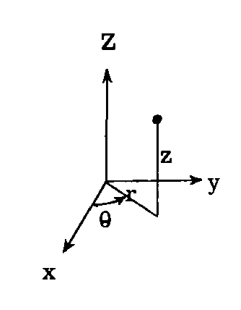

円筒座標系

ここで、 $r, z, \theta$ 方向の体積力成分はそれぞれ $R, Z, \Theta$ として識別され、球座標 $r, \theta, \phi$ では：

$$\begin{aligned}
\frac{\partial \sigma_r}{\partial r} + \frac{1}{r} \frac{\partial \tau_{r\theta}}{\partial \theta} + \frac{1}{r \sin \theta} \frac{\partial \tau_{r\phi}}{\partial \phi} + \frac{1}{r} (2\sigma_r - \sigma_\theta - \sigma_\phi + \tau_{r\theta} \cot \theta) + R &= 0 \\
\frac{\partial \tau_{r\theta}}{\partial r} + \frac{1}{r} \frac{\partial \sigma_\theta}{\partial \theta} + \frac{1}{r \sin \theta} \frac{\partial \tau_{\theta\phi}}{\partial \phi} + \frac{1}{r} [(\sigma_\theta - \sigma_\phi) \cot \theta + 3\tau_{r\theta}] + \Theta &= 0 \\
\frac{\partial \tau_{r\phi}}{\partial r} + \frac{1}{r} \frac{\partial \tau_{\theta\phi}}{\partial \theta} + \frac{1}{r \sin \theta} \frac{\partial \sigma_\phi}{\partial \phi} + \frac{1}{r} [3\tau_{r\phi} + 2\tau_{\theta\phi} \cot \theta] + \Phi &= 0
\end{aligned}$$

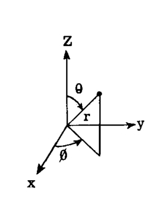

球座標系

ここで、 $r, \theta, \phi$ 方向の体積力はそれぞれ $R, \Theta, \Phi$ で与えられる。

### A24.4 ひずみ - 変位関係

6つの未知数 $\sigma_x, \sigma_y, \sigma_z, \tau_{xy}, \tau_{xz}, \tau_{yz}$ に対して3つの方程式である式(2), (3), (4)は、これらの未知数に対する解を確立するには不十分である。したがって、完全なセットを提供するために必要なさらなる方程式として、応力を変形可能な弾性体の変形に関連付ける方程式に目を向ける。まず、ひずみ変位関係を考える。これらのひずみと応力の間の関係の議論は、その後に続く。

変形前に正の $x$ 方向に単位長さの仮想的なファイバーが存在する場合、変形後のこのファイバーの長さの増加を決定するだけで、ファイバーの始点におけるひずみを得ることができる。この長さの変化が十分に小さいため、この変化の2次項が無視でき、さらに、このファイバーの $x$ 方向からの回転が小さいという仮定のもとで、単純な三角法により、ひずみ $\epsilon_x$ が以下で与えられることを容易に示すことができる。

$$\epsilon_x = \frac{\partial u}{\partial x}
\quad ---\quad (6)$$

元々 $y$ および $z$ 方向にあるファイバーを考慮することにより、弾性学のすべてのテキストに記載されている同じ展開から、以下が得られる。

$$\begin{aligned}
\epsilon_y &= \frac{\partial v}{\partial y} \quad ---\quad (7) \\
\epsilon_z &= \frac{\partial w}{\partial z} \quad ---\quad (8)
\end{aligned}$$

ここで、 $u, v, w$ は、考慮される3つのファイバーの原点である関心のある点の、未変形物体の位置からの変位である。せん断ひずみは、長さの変化とファイバーの回転の大きさに対する同じ制限が適用される場合、同一平面内にある2つのファイバーを考慮することによって容易に得られる。物体内の関心のある点 $O$ から始まる $x-y$ 平面内のこれら2つの投影を考える。

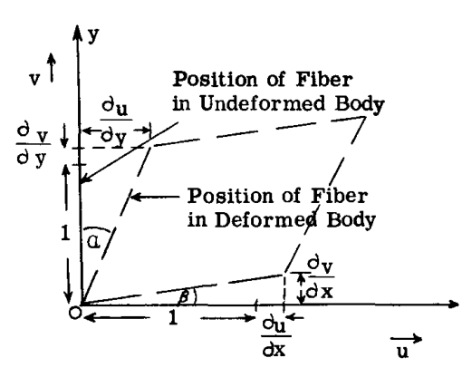

x-y平面におけるファイバーの変形

せん断ひずみは、上述の仮定内で $\gamma_{xy} = \alpha + \beta = \frac{\partial u}{\partial y} + \frac{\partial v}{\partial x}$ となる。同様の方法で、せん断ひずみの残りの2つの成分を得て、完全なセットを与えることができる。

$$\begin{aligned}
\gamma_{xy} &= \frac{\partial u}{\partial y} + \frac{\partial v}{\partial x} \quad ---\quad (9) \\
\gamma_{xz} &= \frac{\partial w}{\partial x} + \frac{\partial u}{\partial z} \quad ---\quad (10) \\
\gamma_{yz} &= \frac{\partial v}{\partial z} + \frac{\partial w}{\partial y} \quad ---\quad (11)
\end{aligned}$$

将来の便宜のために、これらのひずみ変位関係を以下に円筒座標および球座標で記述する。

円筒座標では、

$$\begin{aligned}
\epsilon_r &= \frac{\partial u}{\partial r} ;\quad \epsilon_z = \frac{\partial w}{\partial z} ;\quad \epsilon_\theta = \frac{u}{r} + \frac{1}{r} \frac{\partial v}{\partial \theta} \\
\gamma_{r\theta} &= \frac{1}{r} \frac{\partial u}{\partial \theta} + \frac{\partial v}{\partial r} - \frac{v}{r} ;\quad \gamma_{rz} = \frac{\partial u}{\partial z} + \frac{\partial w}{\partial r} ;\\
\gamma_{z\theta} &= \frac{\partial v}{\partial z} + \frac{1}{r} \frac{\partial w}{\partial \theta}
\end{aligned}$$

ここで、 $u, v, w$ はそれぞれ $r, \theta, z$ 方向の変位を表す。また、球座標では、

$$\begin{aligned}
\epsilon_r &= \frac{\partial u}{\partial r} ;\quad \epsilon_\theta = \frac{u}{r} + \frac{1}{r} \frac{\partial v}{\partial \theta} ;\\
\epsilon_\phi &= \frac{u}{r} + \frac{v}{r} \cot \theta + \frac{1}{r \sin \theta} \frac{\partial w}{\partial \phi} \\
\gamma_{r\theta} &= \frac{1}{r} \frac{\partial u}{\partial \theta} + \frac{\partial v}{\partial r} - \frac{v}{r} \\
\gamma_{r\phi} &= \frac{1}{r \sin \theta} \frac{\partial u}{\partial \phi} + \frac{\partial w}{\partial r} - \frac{w}{r} \\
\gamma_{\theta\phi} &= \frac{1}{r} \left(\frac{\partial w}{\partial \theta} - w \cot \theta\right) + \frac{1}{r \sin \theta} \frac{\partial v}{\partial \phi}
\end{aligned}$$

ここで、 $u, v, w$ はそれぞれ $r, \theta, \phi$ 方向の変位を表す。

これらの方程式は、変位の大きさのオーダーに関する制限的な仮定の下でのみ適用されることに注意しなければならない。これらは、古典弾性論の線形ひずみ-変位関係である。古典理論への明白な拡張は、変位微分の高次項が考慮される大変形理論として直ちに現れる。この困難な非線形理論は現在、活発に研究されている。

座屈や構造物のポスト座屈挙動などの多くの構造問題は大変形を伴うため、開発が進められている。

これで、3つの釣り合い方程式と6つのひずみ変位関係からなる9つの方程式があり、15の未知数 $\sigma_x, \sigma_y, \sigma_z, \tau_{xy}, \tau_{yz}, \tau_{xz}, \epsilon_x, \epsilon_y, \epsilon_z, \gamma_{xy}, \gamma_{yz}, \gamma_{xz}, u, v, w$ が存在するため、方程式系は以前よりもさらに不完全である。しかし、応力ひずみ関係、すなわちフックの法則により、方程式系は15に完了する。

### A24.5 応力 - ひずみ関係

線形弾性論の制限的仮定に従い、フックの法則の一般的な表現は、等温問題において36個の定数を必要とする。等方性材料、すなわち、体積全体を通じた任意の選択された点において、考えられるすべての観察方向に対して弾性特性が同じである材料については、これら36個の定数は容易に依存関係にあることが示され[^1][^2][^3][^4]、最も一般的に使用される2つの定数、 $E$ （ヤング率）と $u$ （ポアソン比）、またはラメの定数 $\lambda$ と $\mu$ に減らすことができる。等温問題に対して、応力ひずみ関係は以下のように書くことができる。

$$\begin{aligned}
\epsilon_x &= \frac{1}{E} [\sigma_x -
u(\sigma_y + \sigma_z)] \\
\epsilon_y &= \frac{1}{E} [\sigma_y -
u(\sigma_z + \sigma_x)] \\
\epsilon_z &= \frac{1}{E} [\sigma_z -
u(\sigma_y + \sigma_x)] \\
\gamma_{xy} &= \frac{1}{G} \tau_{xy} \\
\gamma_{yz} &= \frac{1}{G} \tau_{yz} \\
\gamma_{xz} &= \frac{1}{G} \tau_{xz}
\end{aligned}$$

ラメの線形定数を用いて応力ひずみ関係を表現する方が便利な場合が多い。3次元弾性において、これらの関係は以下のようになる。

$$\begin{aligned}
\sigma_x &= \lambda e + 2\mu \epsilon_x \\
\sigma_y &= \lambda e + 2\mu \epsilon_y \\
\sigma_z &= \lambda e + 2\mu \epsilon_z \\
\tau_{xy} &= \mu \gamma_{xy} \\
\tau_{yz} &= \mu \gamma_{yz} \\
\tau_{zx} &= \mu \gamma_{zx}
\end{aligned}$$

ここで、ラメの定数は、

$$\lambda = \frac{
u E}{(1 +
u)(1 - 2
u)}$$

$$\mu = \frac{E}{2(1 +
u)} = G$$

および、

$$e = \epsilon_x + \epsilon_y + \epsilon_z = \text{体積要素の体積膨張（dilatation）}$$

さらに、以下に注意すべきである。

$$3\lambda + 2\mu = 3k$$

ここで、

$$k = \frac{E}{3(1 - 2
u)}$$

加熱された弾性体の場合、これらのひずみの表現は、すべての構造材料の熱膨張特性から生じる成分の追加によって修正されなければならない。この成分は、何らかの基準温度（通常は室温）の上または下の温度レベル $T$ に比例する。比例定数は、よく知られた線熱膨張係数 $\alpha$ であり、等方性材料の場合、点 $O$ におけるすべての観察方向で同じである。 $x, y, z$ 方向にそれぞれ配向された仮想的なファイバーの単位長さあたりの長さの変化である直接ひずみ成分 $\epsilon_x, \epsilon_y, \epsilon_z$ が、熱膨張によって直接影響を受けることは明らかである。しかし、等方性材料の場合、 $O$ に位置する小さな体積要素の等方的な膨張中に角度変形は変化しないため、せん断応力成分は影響を受けない。したがって、熱弾性力学の応力ひずみ関係は次のようになる。

$$\epsilon_x = \frac{1}{E} [\sigma_x -
u(\sigma_y + \sigma_z)] + \alpha T
\quad ---\quad (12)$$

$$\epsilon_y = \frac{1}{E} [\sigma_y -
u(\sigma_x + \sigma_z)] + \alpha T
\quad ---\quad (13)$$

$$\epsilon_z = \frac{1}{E} [\sigma_z -
u(\sigma_x + \sigma_y)] + \alpha T
\quad ---\quad (14)$$

$$\gamma_{xy} = \frac{1}{G} \tau_{xy}
\quad ---\quad (15)$$

$$\gamma_{xz} = \frac{1}{G} \tau_{xz}
\quad ---\quad (16)$$

$$\gamma_{yz} = \frac{1}{G} \tau_{yz}
\quad ---\quad (17)$$

これらの方程式は、応力をひずみの関数として表すために反転させることができる。これは学生への演習として残されているが、ラメの定数を含むこれらの関係は、処理の完全性のためにここに示されている。

$$\begin{aligned}
\sigma_x &= \lambda e + 2\mu\epsilon_x - (3\lambda + 2\mu)\alpha T \\
\sigma_y &= \lambda e + 2\mu\epsilon_y - (3\lambda + 2\mu)\alpha T \\
\sigma_z &= \lambda e + 2\mu\epsilon_z - (3\lambda + 2\mu)\alpha T \\
\tau_{xy} &= \mu\gamma_{xy} \\
\tau_{yz} &= \mu\gamma_{yz} \\
\tau_{zx} &= \mu\gamma_{zx}
\end{aligned}$$

ここで、 $\lambda, \mu$ および $e$ の定義は、応力とひずみを関連付ける等温方程式において以前に与えられたものから変更されていない。

### A24.6 3次元熱弾性力学の一般方程式

未知数は以下の通りである：

- 6つの応力成分 $\sigma_x, \sigma_y, \sigma_z, \tau_{xy}, \tau_{xz}, \tau_{yz}$
- 6つのひずみ成分 $\epsilon_x, \epsilon_y, \epsilon_z, \gamma_{xy}, \gamma_{xz}, \gamma_{yz}$
- 3つの変位成分 $u, v, w$ 合計 15

必要な15の方程式は、以下によって与えられる：

#### 3つの釣り合い方程式

$$\begin{aligned}
\frac{\partial \sigma_x}{\partial x} + \frac{\partial \tau_{xy}}{\partial y} + \frac{\partial \tau_{xz}}{\partial z} + X &= 0 \\
\frac{\partial \sigma_y}{\partial y} + \frac{\partial \tau_{xy}}{\partial x} + \frac{\partial \tau_{yz}}{\partial z} + Y &= 0 \\
\frac{\partial \sigma_z}{\partial z} + \frac{\partial \tau_{xz}}{\partial x} + \frac{\partial \tau_{yz}}{\partial y} + Z &= 0
\end{aligned}$$

#### 6つのひずみ - 変位関係

$$\begin{aligned}
\epsilon_x &= \frac{\partial u}{\partial x} \\
\epsilon_y &= \frac{\partial v}{\partial y} \\
\epsilon_z &= \frac{\partial w}{\partial z}
\end{aligned}
\quad\quad
\begin{aligned}
\gamma_{xy} &= \frac{\partial u}{\partial y} + \frac{\partial v}{\partial x} \\
\gamma_{yz} &= \frac{\partial v}{\partial z} + \frac{\partial w}{\partial y} \\
\gamma_{xz} &= \frac{\partial u}{\partial z} + \frac{\partial w}{\partial x}
\end{aligned}$$

#### 6つのひずみ - 応力関係

$$\begin{aligned}
\epsilon_x &= \frac{1}{E} [\sigma_x -
u(\sigma_y + \sigma_z)] + \alpha T \\
\epsilon_y &= \frac{1}{E} [\sigma_y -
u(\sigma_x + \sigma_z)] + \alpha T \\
\epsilon_z &= \frac{1}{E} [\sigma_z -
u(\sigma_x + \sigma_y)] + \alpha T \\
\gamma_{xy} &= \frac{1}{G} \tau_{xy} \\
\gamma_{xz} &= \frac{1}{G} \tau_{xz} \\
\gamma_{yz} &= \frac{1}{G} \tau_{yz}
\end{aligned}$$

独立した方程式の数が未知数の数に等しいため、方程式系はこれで完全である。

### A24.7 適合方程式（互換方程式）

ひずみ変位方程式において、3つの変位成分を定義するために6つのひずみ成分が必要であることに注意されたい。したがって、仮に6つのひずみ成分のセットをランダムに選択したとしても、ひずみ変位方程式を満たす3つの変位成分のセットが存在するとは限らない。

したがって、これら6つのひずみ成分の選択は任意ではあり得ず、実際、ひずみ成分の微分を関連付ける方程式である適合方程式が満たされなければならない。したがって、これらの適合方程式は、連続的な一価の変位関数の存在を保証する。これはもちろん、分析が応力とひずみのみで定式化される場合に、解の唯一性を保証する。これらの方程式は、完全な15の方程式セットが満たされる場合、自動的に満たされる。

これらの方程式は、次の方法で導出される。式(9)から：

$$\gamma_{xy} = \frac{\partial u}{\partial y} + \frac{\partial v}{\partial x}$$

したがって、

$$\begin{aligned}
\frac{\partial^2 \gamma_{xy}}{\partial x \partial y} &= \frac{\partial^3 u}{\partial x \partial y^2} + \frac{\partial^3 v}{\partial x^2 \partial y} \\
&= \frac{\partial^2}{\partial y^2} \left(\frac{\partial u}{\partial x}\right) + \frac{\partial^2}{\partial x^2} \left(\frac{\partial v}{\partial y}\right)
\end{aligned}$$

または式(6)と(7)から、

$$\frac{\partial^2 \gamma_{xy}}{\partial x \partial y} = \frac{\partial^2 \epsilon_x}{\partial y^2} + \frac{\partial^2 \epsilon_y}{\partial x^2}$$

残りの5つの適合方程式も同様の方法で導出され、完全なセットは以下のようになる。

$$\frac{\partial^2 \gamma_{xy}}{\partial x \partial y} = \frac{\partial^2 \epsilon_x}{\partial y^2} + \frac{\partial^2 \epsilon_y}{\partial x^2}
\quad ---\quad (18)$$

$$\frac{\partial^2 \gamma_{xz}}{\partial x \partial z} = \frac{\partial^2 \epsilon_x}{\partial z^2} + \frac{\partial^2 \epsilon_z}{\partial x^2}
\quad ---\quad (19)$$

$$\frac{\partial^2 \gamma_{yz}}{\partial y \partial z} = \frac{\partial^2 \epsilon_y}{\partial z^2} + \frac{\partial^2 \epsilon_z}{\partial y^2}
\quad ---\quad (20)$$

$$\frac{\partial}{\partial z} \left( \frac{\partial \gamma_{yz}}{\partial x} + \frac{\partial \gamma_{xz}}{\partial y} - \frac{\partial \gamma_{xy}}{\partial z} \right) = 2 \frac{\partial^2 \epsilon_z}{\partial x \partial y}
\quad ---\quad (21)$$

$$\frac{\partial}{\partial x} \left( \frac{\partial \gamma_{xz}}{\partial y} + \frac{\partial \gamma_{xy}}{\partial z} - \frac{\partial \gamma_{yz}}{\partial x} \right) = 2 \frac{\partial^2 \epsilon_x}{\partial y \partial z}
\quad ---\quad (22)$$

$$\frac{\partial}{\partial y} \left( \frac{\partial \gamma_{xy}}{\partial z} + \frac{\partial \gamma_{yz}}{\partial x} - \frac{\partial \gamma_{xz}}{\partial y} \right) = 2 \frac{\partial^2 \epsilon_y}{\partial x \partial z}
\quad ---\quad (23)$$

後で指摘するように、問題が変位の観点から定式化され、一般解が変位の観点で書かれた釣り合い方程式のみを満たさなければならない場合、これらの適合方程式は自動的に満足される。比較として、問題が応力の観点から完全に定式化される場合は、釣り合い方程式と適合方程式の両方が満足されなければならない。3つの釣り合い方程式と6つの応力ひずみ関係、および6つの適合方程式を合わせることで、応力とひずみのみの観点から定式化された問題に対する一般解のための完全な方程式セットが再び提供される。

あとは、選択された物理的問題に対して、この完全な方程式セットの特定解を得るだけである。これには、一般解を代入して、一般解に存在する未知の定数を評価できる代数方程式のセットを得るための、境界条件を記述する方程式の使用が必要である。

### A24.8 境界条件

境界条件は、3つの異なる可能な方法で規定できることは明らかである。それぞれのケースを順番に考えてみよう。

- **ケース 1.** すべての外側境界条件が、幾何学的拘束が課されない外側表面荷重の観点から規定されている。導出された方程式は応力の観点から書かれているため、これらの荷重は荷重強度（ポンド力/単位面積）に変換され、表面力（surface tractions）と呼ばれる。これらの境界条件を持つシステムの簡単な例としては、静水圧を受ける一般的な3次元弾性体や、不均一に加熱された同一の物体が挙げられる。最初の例では、表面力は表面に垂直に作用する圧力レベルであり、後者の例では、表面は力から解放されている（境界の表面力はすべてゼロ）。表面の任意の点における表面力が、それぞれ $x, y, z$ 軸に平行なベクトル成分 $\bar{X}, \bar{Y}, \bar{Z}$ によって表される場合、境界における釣り合い方程式は、以下の境界条件方程式を与える。

$$\begin{aligned}
\bar{X} &= \sigma_x l + \tau_{xy} m + \tau_{xz} n \\
\bar{Y} &= \sigma_y m + \tau_{yz} n + \tau_{xy} l \\
\bar{Z} &= \sigma_z n + \tau_{xz} l + \tau_{yz} m
\end{aligned}
\quad ---\quad (24)$$

ここで、 $l, m, n$ は、外側に向かって引かれた表面法線の方向余弦である。

- **ケース 2.** すべての外側境界が幾何学的拘束によって拘束されており、したがって、すべての境界変位が規定されている。このケースは、工学構造物においては比較的稀である。簡単な例としては、剛体内に完全に含まれる加熱されたインサートが挙げられる。境界全体にわたって変位が規定されている場合、境界条件は以下のように書くことができる。

$$\left.\begin{aligned}
u &= f(s) \\
v &= g(s) \\
w &= h(s)
\end{aligned}\right\}
\quad ---\quad (25)$$

ここで、 $s$ は表面の点であり、 $f, g, h$ は規定された変位によって処方される既知の関数である。

- **ケース 3.** 境界条件が、表面の一部では応力によって規定され、残りの部分では変位によって規定されている。簡単な例としては、加熱された片持ち翼があり、剛な翼根固定の仮定は翼根におけるゼロ変位を処方する一方、構造物表面の残りの部分では、無荷重の翼に対して表面力はゼロとなるか、または

外力によって規定される。この問題については、本テキストの章 A25で後に詳しく説明する。上記の2つのケースで述べた両方の方程式セットは、必要に応じて適切に使用されなければならない。

### A24.9 一般的な注意事項

ここでは熱弾性力学の線形理論のみを考慮しているため、重ね合わせの理が適用される。これはもちろん、複数の原因の1つによる弾性構造物の応力、ひずみ、および変位を決定し、独立して処理された各原因の結果を足し合わせて、同時に作用するすべての原因による応力、ひずみ、および変位を決定できることを意味する。加熱され荷重を受け持つ構造物の熱弾性解析においては、温度のみによる応力、ひずみ、および変位の分布を決定し、この結果に、十分に文書化された弾性論に従って荷重を受け持つ構造物の等温解析を加えて最終的な分布を得ることが、非常に便利な場合が多い。温度による応力、ひずみ、および変位を決定する際、等温解析において温度による幾何学的拘束での変形が、以下のような境界条件方程式によって規定された値に回復される限り、すべての表面を力から解放されていると正しく考えることができる。

$$\left.\begin{aligned}
u &= f(s) - u_T(s) \\
v &= g(s) - v_T(s) \\
w &= h(s) - w_T(s)
\end{aligned}\right\}
\quad ---\quad (26)$$

関数 $u_T, v_T, w_T$ は、すべての表面が力から解放されていると考えた熱弾性解析から計算された境界変位となる。

この手法には、熱弾性問題を常に応力のみで定式化でき、混合境界条件問題を等温解析に委ねることができるという明確な利点がある。しかし、これが常に有利であるとは限らず、熱解析と等温解析の両方で規定の境界変位条件を維持することが望ましい場合が多いことが後に示される。残念ながら選択の規則を与えることはできず、決定は解析者自身の経験に基づいて行われなければならない。しかし、次の章で考慮される例はこの選択を助けるであろう。

上述において、応力定式化についての言及がなされた。この点は明確にする必要がある。3次元弾性力学および熱弾性力学の15の方程式は、15の未知の応力、ひずみ、および変位成分を含んでいる。境界条件が前セクションのケース1のように表面力のみで与えられる場合、境界条件方程式は6つの応力成分を含んでいる。したがって、15の方程式を6つの応力方程式の観点から定式化することが望ましい。これらは、3つの釣り合い方程式と、応力ひずみおよびひずみ変位関係を用いて応力の観点で書かれた最初の3つの適合方程式となる。一意の解を保証するために、残りの3つの適合方程式も満足されなければならない。特定解は、9つの方程式セットと3つの境界条件関係から、応力のみの観点から得られる。この定式化は、すべての表面が力から解放されていると考えられる熱応力解析で採用されるものである。この応力定式化において、釣り合い方程式と（応力の観点で書かれた）適合方程式が一般解によって同時に満たされなければならないことを覚えておくことが重要である。

一方、境界条件がケース2のものである場合、境界条件方程式は3つの既知の変位のみを含んでいる。その場合、問題は変位の観点から定式化される。境界を越える変位の選択により、適合方程式は自動的に満たされるため、応力ひずみおよびひずみ変位関係を使用して変位の観点から書き直された3つの釣り合い方程式の解を得るだけでよい。残念ながら、前述のように、この最も望ましいケースが工学解析において存在することは稀である。

境界条件がケース3の混合型である場合、どちらの定式化も他方より望ましいということはない。

#### 参考文献

1. “Theory of Elasticity” by S. Timoshenko, McGraw-Hill Book Co., Inc., New York, N.Y.
2. “Mathematical Theory of Elasticity” by A.E.H. Love; Dover Publications, New York, 1944.
3. “Analysis of Stress and Strain” by A. J. Durelli, E. A. Phillips and C. H. Tsao, McGraw-Hill Book Co., Inc., New York, N.Y.
4. “Mathematical Theory of Elasticity” by I.S. Sokolnikoff, McGraw-Hill Book Co., Inc., New York, N.Y.

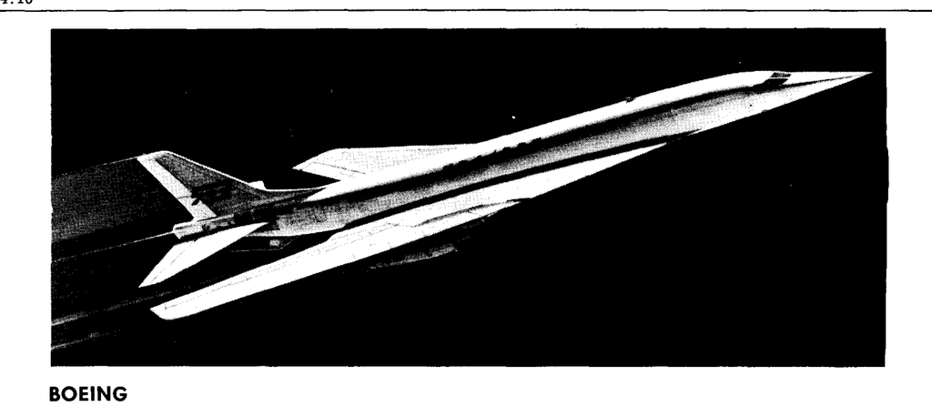

超音速旅客機の提案デザイン。ボーイングがコンペティションで勝利したが、後に固定翼タイプにデザインを変更した。その後、議会はSSTプロジェクトを中止したが、これは著者の意見では誤った決定であった。

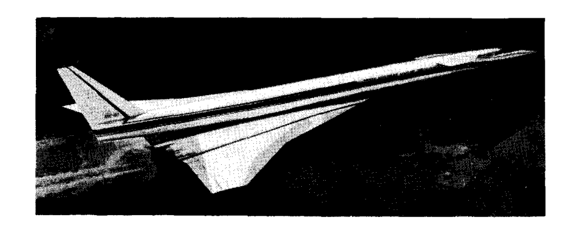

NORTH AMERICAN

[figure not shown]

LOCKHEED

[^1]: カッコ内の数字は、章末の参考文献を参照している。
[^2]: カッコ内の数字は、章末の参考文献を参照している。
[^3]: カッコ内の数字は、章末の参考文献を参照している。
[^4]: カッコ内の数字は、章末の参考文献を参照している。